# マルチレベルモデリングChapter6:非線形モデリング(非連続モデル)

UPDATE: 2022-11-30 15:07:26

# はじめに

[縦断データの分析I―変化についてのマルチレベルモデリング―](https://www.asakura.co.jp/detail.php?book_code=12191)を利用してマルチレベルモデリングの勉強内容をまとめたもの。下記のサポートサイトにサンプルデータなどが保存されている。

- [TEXTBOOK EXAMPLES APPLIED LONGITUDINAL DATA ANALYSIS](https://stats.oarc.ucla.edu/other/examples/alda/)

ここでの目的は、非線形なモデリング方法についてまとめておく。

## 非連続レベル1モデル

個々の変化が非線形であるモデルを適合させる方法をここではまとめていく。

使用するデータは、ここでも男子高校生の中退者の労働市場経験と賃金の関係を追跡したデータを利用する。このデータは下記の特徴を持っている。

- 最初の時点で年齢が14歳から17歳までばらついている
- 測定の間隔が1年後であったり、2年後の場合もある
- 調査月もバラバラな状態
- 面接調査のときに2つ以上の仕事に回答できる
- 異なる時期に退学して、異なる時期に就職して、異なる時期に転職できる

`lnw`は自然対数変換された賃金で、$e^{2.03}=7.6$ドルとなる。`exper`は時間的な変数であり`lnw`の観測値と関連付けられた特定の時点を表す。例えば、`id=206`は3回の測定回数をもっており、`1.87, 2.81, 4.31`年経過後を意味している。転職すると、調査があって、レコードが生成されるというイメージ。白人ラテン系(`black=0`)でありアフリカ系(`black=1`)である。また、`hgc`は修了年数で、`hgc.9`は9を引いて中心化しているので、`0`は9年生、`3`は12年生を意味する。

今回あらたに利用する変数`ged`は高卒認定資格のようなもので、`0`または`1`をとる時変変数であり、取得前は`0`を表し、取得後は`1`を表す。必ずしも全員が取得するわけではないので、観察期間中すべて`0`の個人もいる。

また、`postexp`は`ged`取得後に値が0より大きくなる変数で、`exper`との差分を値として持ち、`ged`取得後の1つ後ろの時点(`ged`取得時点での`postexp`は`0`)から時間経過とともに累計されるように作られている。モデルの解釈をしやすいように変数がこのように加工されている。

```r
library(tidyverse)
library(broom)
library(nlme)
library(DT)
library(patchwork)
library(stargazer)
wages <- read.table("https://stats.idre.ucla.edu/stat/r/examples/alda/data/wages_pp.txt", header=T, sep=",")
wages$ged.exper <- wages$ged*wages$exper
datatable(wages %>% select(id, lnw, exper, ged, postexp, ged.exper, black, hgc.9, uerate) %>% filter(id %in% c(206,2365,4384)) %>% mutate_if(is.numeric, round, 2))
```

|  | id | lnw | exper | ged | postexp | ged.exper | black | hgc.9 | uerate |
| --- | --- | --- | --- | --- | --- | --- | --- | --- | --- |
| 1 | 206 | 2.03 | 1.87 | 0 | 0 | 0 | 0 | 1 | 9.2 |
| 2 | 206 | 2.3 | 2.81 | 0 | 0 | 0 | 0 | 1 | 11 |
| 3 | 206 | 2.48 | 4.31 | 0 | 0 | 0 | 0 | 1 | 6.3 |
| 4 | 2365 | 1.78 | 0.66 | 0 | 0 | 0 | 0 | 1 | 5.7 |
| 5 | 2365 | 1.76 | 1.68 | 0 | 0 | 0 | 0 | 1 | 8.2 |
| 6 | 2365 | 1.71 | 2.74 | 0 | 0 | 0 | 0 | 1 | 9.8 |
| 7 | 2365 | 1.74 | 3.68 | 0 | 0 | 0 | 0 | 1 | 10.9 |
| 8 | 2365 | 2.19 | 4.68 | 1 | 0 | 4.68 | 0 | 1 | 6.8 |
| 9 | 2365 | 2.04 | 5.72 | 1 | 1.04 | 5.72 | 0 | 1 | 7.21 |
| 10 | 2365 | 2.32 | 6.72 | 1 | 2.04 | 6.72 | 0 | 1 | 7.21 |

[output cut: 12 more lines]

ここでやりたいことを個人経験プロットとして可視化して確認しておく。例えば、緑であれば`ged=1`のあとは賃金が増加しているようにも見える。つまり、`ged`が賃金に関して、その時点で切片を押し上げているかも知れないし、傾き自体を変化させているかもしれない。このような非連続な変化をするモデルをここでは扱う。

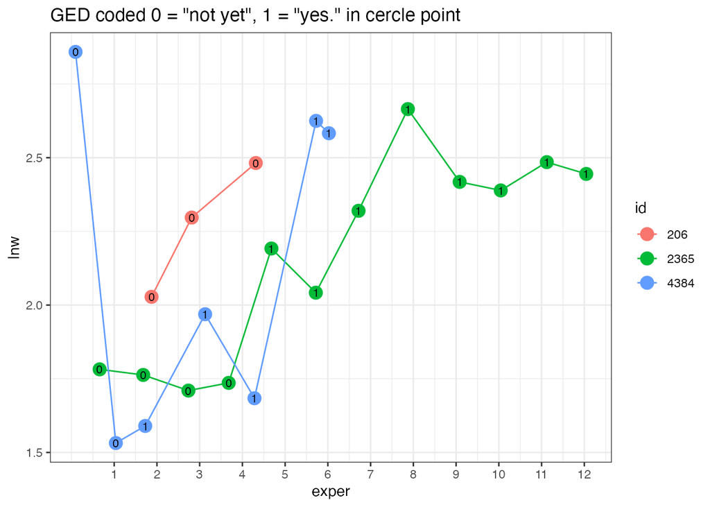

```r
wages %>%
  filter(id %in% c(206, 2365, 4384)) %>%
  mutate(id = factor(id)) %>%
  ggplot(aes(x = exper, y = lnw)) +
  geom_point(aes(color = id), size = 4) +
  geom_line(aes(color = id)) +
  geom_text(aes(label = ged), size = 3) +
  scale_x_continuous(breaks = 1:13) +
  ggtitle('GED coded 0 = "not yet", 1 = "yes." in cercle point') +
  theme_bw()
```

## 非連続な変化のパターン

`ged`の前後の関係から高さと傾きの変化を考えると、簡略化した尤もらしい4つのパターンが考えられる。尤もらしいというだけで他にも無数にある。`ged`が取るタイミングがおそくなると、タイミングによっては`ged`の効果は弱くなる可能性も考えられる。

- 高さの無変化と傾きの無変化(赤)
- 高さの変化と傾きの無変化(緑)
- 高さの無変化と傾きの変化(青)
- 高さの変化と傾きの変化(紫)

下記は労働市場3年目に`GED`の効果が出た場合の変化のパターンを可視化したもの。これらのモデルを以降で深堀りしていく。

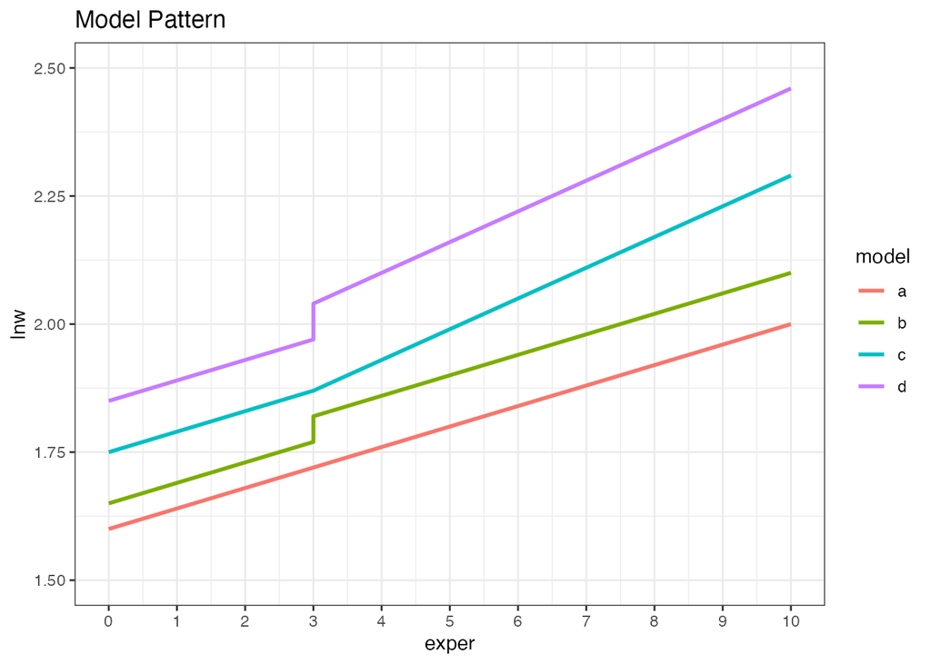

```r
tibble(exper = c(0, 3, 3, 10), ged = rep(0:1, each = 2)) %>%
  expand(model = letters[1:4], nesting(exper, ged)) %>%
  mutate(exper2 = if_else(ged == 0, 0, exper - 3)) %>%
  mutate(lnw = case_when(
    model == "a" ~ 1.60 + 0.04 * exper,
    model == "b" ~ 1.65 + 0.04 * exper + 0.05 * ged,
    model == "c" ~ 1.75 + 0.04 * exper + 0.02 * exper2 * ged,
    model == "d" ~ 1.85 + 0.04 * exper + 0.01 * ged + 0.02 * exper * ged
  )) %>%
  ggplot(aes(x = exper, y = lnw)) +
  geom_line(aes(color = model), size = 1) +
  scale_x_continuous(breaks = seq(0, 10, 1)) +
  scale_y_continuous(breaks = seq(0, 3, 0.25), limits = c(1.5, 2.5)) +
  ggtitle("Model Pattern") +
  theme_bw()
```

## 高さの変化と傾きの無変化(緑)

高さの変化と傾きの無変化(緑)のパターンをモデル化すると下記の通り。傾きではなく、直線の高さに変化が出るパターンなので、そのまま`GED`をモデルに取り込めば良い。`GED=0`までは時間経過ととも変化する直線で、`GED=1`からは軌跡の高さが$\pi_{2i}$の分だけかさ上げされる。つまり`GED`前後で切片が異なる。

$$\begin{eqnarray}
Y_{ij} &=& \pi_{0i} + \pi_{1i} EXPER_{ij} + \pi_{2i} GED_{ij} +
\epsilon_{ij} \\
if \ GED = 0 \\
Y_{ij} &=& \pi_{0i} + \pi_{1i} EXPER_{ij} + \epsilon_{ij} \\
if \ GED = 1 \\
Y_{ij} &=& (\pi_{0i} + \pi_{2i}) + \pi_{1i} EXPER_{ij} +
\epsilon_{ij}
\end{eqnarray}$$

## 高さの無変化と傾きの変化(青)

高さの無変化と傾きの変化(青)のパターンをモデル化すると下記の通り。このモデルは高さに`GED`の効果は表れないが、傾きに変化がでるパターン。`POSTEXP`は`EXPER`の関係は、両者は全く同じ割合で増加するという関係にある。こうすることで、予測変数の1単位の変化が、他の予測変数との1単位の増加と同時に起こることになる。その結果、パラメタの解釈が簡単になる。

つまり、`GED`取得前の傾きは$\pi_{1i}$で、時間の1単位の差に対する賃金への変化を表し、`GED`取得後は、`POSTEXP`の1単位の増加は、`EXPER`の1単位の増加に付随して起こるので、傾きは$\pi_{1i} + \pi_{3i}$として解釈できる。

$$\begin{eqnarray}
Y_{ij} &=& \pi_{0i} + \pi_{1i} EXPER_{ij} + \pi_{3i}
POSTEXP_{ij} + \epsilon_{ij} \\
if \ GED = 0 \& POSTEXP = 0 \\
Y_{ij} &=& \pi_{0i} + \pi_{1i} EXPER_{ij} + \epsilon_{ij} \\
if \ GED = 1 \& POSTEXP >0\\
Y_{ij} &=& \pi_{0i} + \pi_{1i} EXPER_{ij} + \pi_{3i}
POSTEXP_{ij} + \epsilon_{ij} \\
\end{eqnarray}$$

言葉ではわかりづらいので、計算して確かめておく。`exper`、`postexp`が一緒に同じ割合で変化するというのはどういことなのか。`ged=1`のときから`exper - postexp=4.68`が続いていることがわかる。

```r
wages %>%
  filter(id == 2365) %>%
  filter(ged == 1) %>%  # 可視化の際の一貫性のため
  select(id, ged, exper, postexp) %>%
  mutate(min_exper = min(exper),
         `exper - postexp` = exper - postexp,
        my_postexp = exper - min_exper)
```

```
##     id ged  exper postexp min_exper exper - postexp my_postexp
## 1 2365   1  4.679   0.000     4.679           4.679      0.000
## 2 2365   1  5.718   1.038     4.679           4.680      1.039
## 3 2365   1  6.718   2.038     4.679           4.680      2.039
## 4 2365   1  7.872   3.192     4.679           4.680      3.193
## 5 2365   1  9.083   4.404     4.679           4.679      4.404
## 6 2365   1 10.045   5.365     4.679           4.680      5.366
## 7 2365   1 11.122   6.442     4.679           4.680      6.443
## 8 2365   1 12.045   7.365     4.679           4.680      7.366
```

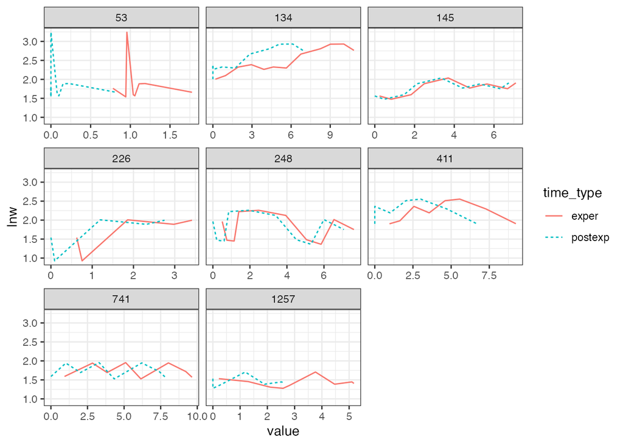

```r
wages %>%
  group_by(id) %>%
  mutate(min_ged = min(ged),
         max_ged = max(ged)) %>%
  filter(min_ged != max_ged) %>%
  filter(id %in% c(53,134,145,226,248,411,741,1257)) %>%
  select(id, ged, lnw, exper, postexp) %>%
  ungroup() %>%
  pivot_longer(c(exper, postexp), names_to = "time_type", values_to = "value") %>%
  ggplot(aes(x = value, y = lnw)) +
  geom_line(aes(linetype = time_type, col = time_type)) +
  facet_wrap(~ id, scales = "free_x") +
  theme_bw()
```

## 高さの変化と傾きの変化(紫)

高さの変化と傾きの変化(紫)のパターンをモデル化すると下記の通り。このモデルは高さにも`GED`の効果が表れ、傾きにも変化がでるパターン。`POSTEXP`は`EXPER`の関係はさきほどと同じ。

$$\begin{eqnarray}
Y_{ij} &=& \pi_{0i} + \pi_{1i} EXPER_{ij} + \pi_{2i} GED_{ij} +
\pi_{3i} POSTEXP_{ij} + \epsilon_{ij} \\
if \ GED = 0 \& POSTEXP = 0 \\
Y_{ij} &=& \pi_{0i} + \pi_{1i} EXPER_{ij} + \epsilon_{ij} \\
if \ GED = 1 \& POSTEXP >0\\
Y_{ij} &=& (\pi_{0i} + \pi_{2i}) + \pi_{1i} EXPER_{ij} +
\pi_{3i} POSTEXP_{ij} + \epsilon_{ij} \\
\end{eqnarray}$$

## 高さの変化と傾きの変化(別)

高さの変化と傾きの変化(別)のパターンは交互作用を入れる方法でもモデル化できる。このモデルでは$\pi_{3i}$の振る舞いが興味深い。つまり$\pi_{3i} (EXPER_{ij} × GED_{ij})$となっていることで、`GED`は`0`または`1`しかとらないが、`GED`を取得するタイミング($EXPER_{ij}$)によって$\pi_{3i}$乗じられる値が異り、加えて$\pi_{2i}$も加算される(理解があまり追いついていない)。

つまり、`GED`を取得したタイミングの高さの差が、経時的な経験により変化することを可能にしている。$\pi_{2i} + \pi_{3i} (EXPER_{ij}$がこれに当たる。

$$\begin{eqnarray}
Y_{ij} &=& \pi_{0i} + \pi_{1i} EXPER_{ij} + \pi_{2i} GED_{ij} +
\pi_{3i} (EXPER_{ij} × GED_{ij}) + \epsilon_{ij} \\
if \ GED = 0 \& POSTEXP = 0 \\
Y_{ij} &=& \pi_{0i} + \pi_{1i} EXPER_{ij} + \epsilon_{ij} \\
if \ GED = 1 \& POSTEXP >0\\
Y_{ij} &=& (\pi_{0i} + \pi_{2i}) + (\pi_{1i} + \pi_{3i}
)EXPER_{ij} + \epsilon_{ij} \\
\end{eqnarray}$$

## どのモデルが妥当なのか

どのモデルが妥当なのかは、仮説や理論に適合するモデルがよい。さきほどのモデルを前提に、これまでに有効と考えられる変数、レベル1の`EXPER`、`UERATE-7`、レベル2の`BLACK`、`HGC-9`をモデルに投入して、マルチレベルモデルを当てはめる。いくつかのモデルを試しているが、基本モデルは下記である。

$$\begin{eqnarray}
Y_{ij} &=& \pi_{0i} + \pi_{1i} EXPER_{ij} + \pi_{2i}
(UERATE_{ij}-7) + \epsilon_{ij} \\
\pi_{0i} &=& \gamma_{00} + \gamma_{01}(HGC_{i}-9) + \zeta_{0i}
\\
\pi_{1i} &=& \gamma_{10} + \gamma_{12}BLACK_{i} + \zeta_{1i} \\
\pi_{2i} &=& \gamma_{20}
\end{eqnarray}$$

```r
model.a <- lme(lnw~exper+hgc.9+exper:black+ue.7        , wages, random= ~ exper         | id, method="ML")
model.b <- lme(lnw~exper+hgc.9+exper:black+ue.7+ged    , wages, random= ~ exper+ged     | id, method="ML")
model.c <- lme(lnw~exper+hgc.9+exper:black+ue.7+ged    , wages, random= ~ exper         | id, method="ML")
model.d <- lme(lnw~exper+hgc.9+exper:black+ue.7+postexp, wages, random= ~ exper+postexp | id, method="ML")
model.e <- lme(lnw~exper+hgc.9+exper:black+ue.7+postexp, wages, random= ~ exper         | id, method="ML")
```

- モデルF：`GED`の高さ、`POSTEXP`の傾きの非連続性を含め、固定効果とランダム効果を得るモデル
- モデルG：モデルFから`POSTEXP`のランダム効果を外したモデル
- モデルH：モデルFから`GED`のランダム効果を外したモデル

```r
control.list <-
  lmeControl(
    maxIter = 500,
    msMaxIter = 500,
    msMaxEval = 500,
    tolerance = 0.1,
    msTol = 0.1,
    sing.tol = 1e-20
  )

model.f <- lme(lnw~exper+hgc.9+exper:black+ue.7+postexp+ged,
               wages,
               random= ~exper+postexp+ged | id,
               method="ML",
               control = control.list)
#2*model.f$logLik
# [1] -4789.354

#anova(model.b, model.f)
#         Model df      AIC      BIC    logLik   Test  L.Ratio p-value
# model.b     1 13 4831.517 4919.454 -2402.759
# model.f     2 18 4825.354 4947.113 -2394.677 1 vs 2 16.16312  0.0064
summary(model.f)
```

```
## Linear mixed-effects model fit by maximum likelihood
##   Data: wages
##        AIC      BIC    logLik
##   4825.354 4947.113 -2394.677
##
## Random effects:
##  Formula: ~exper + postexp + ged | id
##  Structure: General positive-definite, Log-Cholesky parametrization
##             StdDev     Corr
## (Intercept) 0.20330408 (Intr) exper  postxp
## exper       0.03687810 -0.227
## postexp     0.05791491 -0.510 -0.426
## ged         0.12854072  0.453  0.623 -0.534
## Residual    0.30638211
##
## Fixed effects:  lnw ~ exper + hgc.9 + exper:black + ue.7 + postexp + ged
##                  Value   Std.Error   DF   t-value p-value
## (Intercept)  1.7385706 0.011949701 5509 145.49072  0.0000
## exper        0.0414728 0.002798452 5509  14.81990  0.0000
## hgc.9        0.0390242 0.006246369  886   6.24749  0.0000
## ue.7        -0.0117236 0.001783815 5509  -6.57220  0.0000
## postexp      0.0094207 0.005549598 5509   1.69755  0.0896
## ged          0.0408810 0.022011527 5509   1.85726  0.0633
## exper:black -0.0196218 0.004472569 5509  -4.38713  0.0000
##  Correlation:
##             (Intr) exper  hgc.9  ue.7   postxp ged
## exper       -0.531
## hgc.9        0.093 -0.023
## ue.7        -0.368  0.255 -0.045
## postexp      0.159 -0.368 -0.021 -0.012
## ged         -0.323  0.122 -0.020  0.055 -0.559
## exper:black -0.059 -0.297 -0.018  0.067 -0.056  0.007
##
## Standardized Within-Group Residuals:
##         Min          Q1         Med          Q3         Max
## -4.34629563 -0.51338213 -0.03880186  0.44569948  6.97210016
##
## Number of Observations: 6402
## Number of Groups: 888
```

他にも書籍で沢山のモデルを検証しているが、詳細は書籍を参照。ここではモデルFをベターなモデルとして話をすすめる。

```r
# anova(model.d, model.f)
# model.g <- lme(lnw~exper+hgc.9+exper:black+ue.7+postexp+ged, wages, random= ~exper+ged | id, method="ML")
# 2*model.g$logLik
#
# anova(model.f, model.g)
#
# model.h <- lme(lnw~exper+hgc.9+exper:black+ue.7+postexp+ged, wages, random= ~exper+postexp | id, method="ML")
# 2*model.h$logLik
# anova(model.f, model.h)
#
# # 収束しない
# # model.i <- lme(lnw~exper+hgc.9+exper:black+ue.7+ged+exper:ged, wages, random= ~exper+ged+exper:ged | id, method="ML", control = control.list)
# # 2*model.i$logLik
# # anova(model.b, model.i)
#
# model.j <- lme(lnw~exper+hgc.9+exper:black+ue.7+ged+exper:ged, wages, random= ~exper+ged | id, method="ML")
# 2*model.j$logLik
# anova(model.i, model.j)
```

モデルFの理解を深めるために下記の典型的な4人を可視化する。`black`は`0 or 1`で、`hgc.9`は9を引いて中心化しているので、`0`は9年生、`3`は12年生を表す。この典型的な4人は失業率が7%(`ue.7=0`)の地域に住んでいる。また、`GED`は中退から3年目に取得している。

- 白人ラテン系(`black=0`)で9年生(`hgc.9=0`)で中退
- 白人ラテン系(`black=0`)で12年生(`hgc.9=3`)で中退
- アフリカ系(`black=1`)で9年生(`hgc.9=0`)で中退
- アフリカ系(`black=1`)で12年生(`hgc.9=3`)で中退

ここまでくると、モデルが複雑なので、時間を粗くしてモデルのためのグリッドを可視化しておく。

```r
expand_grid(black = 0:1,
                            hgc.9 = c(0, 3),
                            exper = seq(from = 0, to = 11, by = 5),
                            ue.7  = 0) %>%
  mutate(ged      = ifelse(exper < 3, 0, 1),
         postexp  = ifelse(ged == 0, 0, exper - 3)
  )
```

```
## # A tibble: 12 × 6
##    black hgc.9 exper  ue.7   ged postexp
##    <int> <dbl> <dbl> <dbl> <dbl>   <dbl>
##  1     0     0     0     0     0       0
##  2     0     0     5     0     1       2
##  3     0     0    10     0     1       7
##  4     0     3     0     0     0       0
##  5     0     3     5     0     1       2
##  6     0     3    10     0     1       7
##  7     1     0     0     0     0       0
##  8     1     0     5     0     1       2
##  9     1     0    10     0     1       7
## 10     1     3     0     0     0       0
## 11     1     3     5     0     1       2
## 12     1     3    10     0     1       7
```

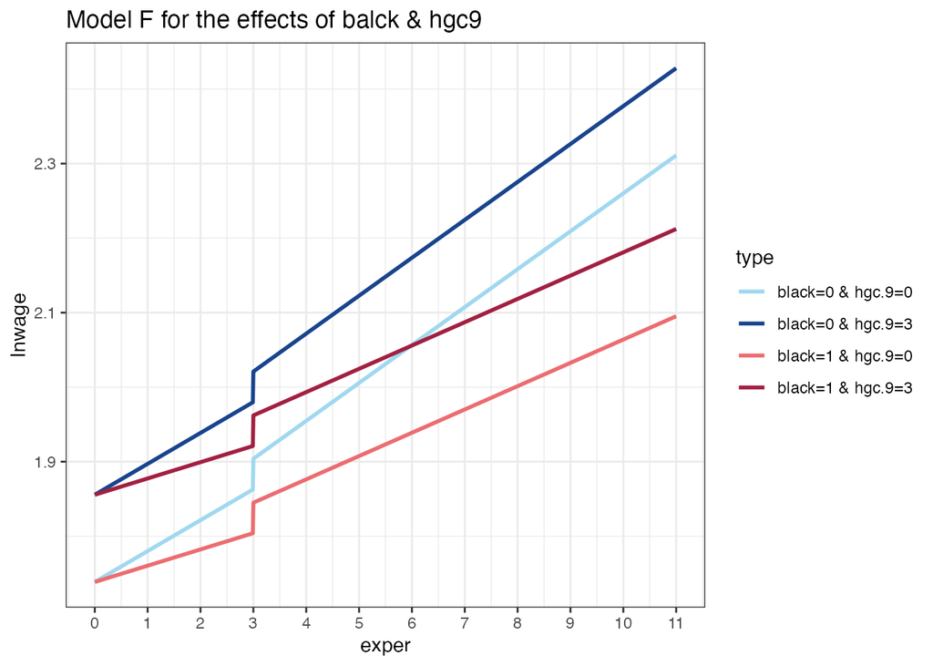

```r
fixef.f <- fixef(model.f)
df_fit_plt_f <- expand_grid(black = 0:1,
                            hgc.9 = c(0, 3),
                            exper = seq(from = 0, to = 11, by = 0.01),
                            ue.7  = 0) %>%
  mutate(ged      = ifelse(exper < 3, 0, 1),
         postexp  = ifelse(ged == 0, 0, exper - 3)
  ) %>%
  mutate(
    lnwage = fixef.f[[1]] +
      fixef.f[[2]] * exper +
      fixef.f[[3]] * hgc.9 +
      fixef.f[[4]] * ue.7 +
      fixef.f[[5]] * postexp +
      fixef.f[[6]] * ged +
      fixef.f[[7]] * exper*black,
         type = paste0("black=", black, " & hgc.9=", hgc.9))

ggplot(df_fit_plt_f, aes(exper, lnwage, col = as.character(type))) +
  geom_path(size = 1) +
  scale_x_continuous(breaks = seq(0, 12, 1)) +
  scale_color_manual(values = c("#a0d8ef", "#19448e", "#ec6d71", "#a22041"), name = "type") +
  xlab("exper") +
  ggtitle("Model F for the effects of balck & hgc9") +
  theme_bw()
```

## 参考文献

- [縦断データの分析I―変化についてのマルチレベルモデリング―](https://www.asakura.co.jp/detail.php?book_code=12191)
- [Applied Longitudinal Data Analysis: Modeling Change and Event Occurrence](https://www.amazon.com/Applied-Longitudinal-Data-Analysis-Occurrence/dp/B017YBZFW0)
- [TEXTBOOK EXAMPLES APPLIED LONGITUDINAL DATA ANALYSIS](https://stats.oarc.ucla.edu/other/examples/alda/)
- [Chapter 9 Mixed Effects Models](https://glennwilliams.me/r4psych/mixed-effects-models.html)
- [Applied longitudinal data analysis in brms and the tidyverse](https://bookdown.org/content/4253/index.html)